# Jupyter Notebooks

This is a jupyter notebook, in this notebook I will demonstrate some of the basics of using jupyter notebooks.

## Cell Types

Jupyter notebooks have two main types of cells

1. markdown cells (like this one)
2. coding cells (like the one below)

```python
# by default, coding cells are in python
print("I am a coding cell")
```

```
I am a coding cell
```

- Markdown cells can be used for creating headings, or for writing commentary about the code, such as explanations or version numbers.
- Coding cells can be used for analysis.

By default the coding language is python and code is run in-line, in the notebook. But you can use bash script (terminal commands) or R in ipython as well.

## Running Terminal Commands in Jupyter Notebooks

If you're just running one command, you can use an exclamation for quick commands.

**Note:** This won't work for `cd`, to change directories you need to use the "magic" cells (cells with %%). However, it is better practice to just use full paths.

```python
!pwd
```

```
/home/hannah/Documents/Fierer_lab/Lab Meeting
```

To make a bash script, you'll need to use "cell magic" like below.

```python
%%bash
for i in a b c;
do
echo $i
done
```

```
a
b
c
```

### Running terminal commands in Jupyter notebooks (the fancy way)

To learn to install the "bash" kernel, see these links:

http://slhogle.github.io/2017/bash_jupyter_notebook/

https://macintoshguy.wordpress.com/2016/04/09/bash-notebooks-in-jupyter/

This will be most useful if you will only be running bash scripts and nothing else from the notebook.

## Running R Commands in Jupyter Notebooks

To run languages other than bash or python, you need to load the extension first. See below:

```python
%load_ext rpy2.ipython
```

To run R in a cell, use the `%%R` symbol.

```python
%%R
library(dplyr)
library(ggplot2)

## If the red warnings bother you, use:

# suppressWarnings(library(tidyverse))
```

```python
%%R
map_file <- read.table("Demo_16S_MappingFile_nopound.txt", sep = "\t", header = TRUE)
```

```python
%%R
map_file %>% mutate(Hello = "Hello")
```

```
    SampleID BarcodeSequence   LinkerPrimerSequence   SampleSite Pooled
1      101.O    CTGTAAAGGTTG CCGGACTACHVGGGTWTCTAAT outdoor trim    yes
2      106.I    CTCTTCTGATCA CCGGACTACHVGGGTWTCTAAT  indoor trim    yes
3      106.O    AACCATGCCAAC CCGGACTACHVGGGTWTCTAAT outdoor trim    yes
4      107.I    CACGATGGTCAT CCGGACTACHVGGGTWTCTAAT  indoor trim    yes
5     1087.O    CCGAAGATTCTG CCGGACTACHVGGGTWTCTAAT outdoor trim    yes
6      109.I    ACATACTGAGCA CCGGACTACHVGGGTWTCTAAT  indoor trim    yes
7     1114.I    CCGACTCTAGGT CCGGACTACHVGGGTWTCTAAT  indoor trim    yes
8     1114.O    AGTCATCGAATG CCGGACTACHVGGGTWTCTAAT outdoor trim    yes
9     1117.I    CGATGTGTGGTT CCGGACTACHVGGGTWTCTAAT  indoor trim    yes
10    1120.I    GAGATCGCCTAT CCGGACTACHVGGGTWTCTAAT  indoor trim    yes
11    1120.O    GTAACCACCACC CCGGACTACHVGGGTWTCTAAT outdoor trim    yes
12    1124.I    TTGGTCTCCTCT CCGGACTACHVGGGTWTCTAAT  indoor trim    yes
13    1124.O    CTTTCGTTCAAC CCGGACTACHVGGGTWTCTAAT outdoor trim    yes
14    1141.O    GGCGTTGCATTC CCGGACTACHVGGGTWTCTAAT outdoor trim    yes
```

[output cut: 739 more lines]

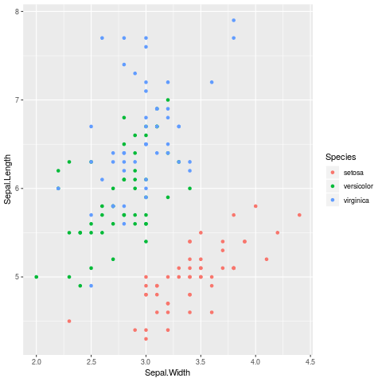

```python
%%R
ggplot(iris, aes(y = Sepal.Length, x = Sepal.Width, color = Species)) +
    geom_point()
```

### Running R Commands in Jupyter Notebooks (the fancy way)

If you only need to run R in your notebook, you can make the entire notebook R, see this page for help: https://irkernel.github.io/installation

## Using Jupyter Notebooks Remotely

Let's say your data is on a remote server (i.e. Microbe) and you want to interact with it through a jupyter notebook. To set this up, follow the steps below:

*This tutorial was adapted from this website: https://amber-md.github.io/pytraj/latest/tutorials/remote_jupyter_notebook*

**Pre-requisites** - make sure jupyter notebook is installed on your own computer and on the server you are trying to connect with.

**Part 1: On the remote server**

1. Open a terminal window and log onto the remote server

   `ssh username@microbe.colorado.edu`
2. `cd` into the directory with your notebook (or the directory where you want to create a new notebook)
3. type `jupyter notebook --no-browser --port=1234`

   **Explanation:**

   `--no-browser`

   This command tells jupyter notebook not to try to launch a browser window, which is good since the default "browser" in a terminal window, is pretty horrible.

   `--port=1234`

   This command tells jupyter notebook that instead of opening a browser it should send the notebook to a special outlet called a port. Ports are specified by numbers, the numbers can be almost anything. It is probably a good idea to make sure that multiple users do not use the same port numbers since conflicts can arrise if two people request the same port at the same time.

**Part 2: On your local computer**

1. Open a second terminal window. On your local computer type `ssh -N -f -L localhost:8888:localhost:1234 username@your_remote_host_name`

   **Explanation:**

   `-N`

   This command works with the `-f` command to help the ssh command run in the background.

   `-f`

   This command tells the terminal to put ssh command in the background just before it runs. This is mainly so that after you run the command, you can still use the terminal that you ran it in.

   `-L`

   This command specifies the port-to-port connections. It is followed by a `localhost:8888:localhost:1234` you can read this as instructions to the computer. "Connect port 8888 on the current host to port 1234 on the remote host."
2. Type in your server password when prompted.
3. Open a web browser (chrome, firefox, etc.) and type localhost:8888 in the address line.

**Don't forget**

You're running the notebook on the server so if you choose to run R in your notebook, you'll need to install all of the R packages on the server before you do that.

## Making Juypter Notebooks Pretty

To make a juypter notebook "pretty" (i.e. formatted the way you want) you need to learn markdown.

Markdown is a simple set of text-only structures that can be interpreted as formatting. It's a simple way to convert a text file into a formated document.

An in-depth guide can be found here: https://daringfireball.net/projects/markdown/syntax#p

Below are some basic examples:

# Header 1

## Header 2

### Header 3

etc..

Making text *italic* or **Bold** or *Bold and italic!*

Bullet points work like this:

- first point
- second point
- third point
  - sub point of three
- Back to 4th point

*Importantly!: in bulletted lists, make sure to put a space between the bullet symbol and the text, otherwise the list will not look right and also be sure to put an empty line before and after your list to make sure the interpreter knows when to stop the list.*

Dashes also work the same way:

- Point number 1
- 2
- 3
  - sub 3
  - bullet character change won't make a difference here
- 4

Numbered lists work like this:

1. Number 1
2. Number 2
3. Number 3
   1. Sub list of 3
4. Number 4

### Blockquotes

> Here is my block quote

> I am quoting a wise person

> > Now I have a second level of quote

### Code

Specify code like this:

`ssh` is a program used to log into remote servers

or like this for multiple lines and to color in a certain language.

```
library(tidyverse)
myfile <- read.table("myfile.txt")
```

### What about special formatting?

You can use inline html for anythin not covered in markdown:

This is my subscript example: H<sub>2</sub>O

Here is a superscript example: <sup>15</sup>N

### Pictures

You can embed images from a file on your computer like this:

[figure not shown]

### Troubleshooting

If something ever unexpectedly carries over to another line when you've deliberately separated the lines you probably need an extra space or two  
at the end of the line or an extra empty line

between the lines.

literal control characters (e.g. *) can usually be specified using the backslash as an escape.

## Saving and Sharing Notebooks

To save and share notebooks, go to `File > Download As` and choose the output file version you'd like to create.

## Shortcuts in Jupyter Notebooks

The command pallet `Cmd\Ctrl + Shift + P` (good for learning commands)

https://www.dataquest.io/blog/jupyter-notebook-tips-tricks-shortcuts/

## Other useful things

### Jupyter User Cheatsheet

https://docs.anaconda.com/_downloads/JupyterLab-Notebook-Cheatsheet.pdf

```python
from IPython.display import HTML
HTML("<iframe src=./JupyterLab-Notebook-Cheatsheet.pdf width=1000, height = 350></iframe>")
```

[interactive chart not shown]

### Making a table of contents

The following extension will create a table of contents https://github.com/shoval/jupyter-navbar